# QM3-GroupWork

**Table 6 :** *log of urban pop*

```r
mod_log_urban_pop<-lm(Renewable_energy_consumption ~ log(Urban_pop), data =recentdata)
stargazer(mod_log_urban_pop, type="text",
          title ="Table 6: OLS results for Renewable Energy Consumption and log(Urban Population)")
```

```
##
## Table 6: OLS results for Renewable Energy Consumption and log(Urban Population)
## ================================================
##                         Dependent variable:
##                     ----------------------------
##                     Renewable_energy_consumption
## ------------------------------------------------
## log(Urban_pop)               -30.712***
##                               (4.426)
##
## Constant                     156.722***
##                               (18.002)
##
## ------------------------------------------------
## Observations                    164
## R2                             0.229
## Adjusted R2                    0.224
## Residual Std. Error      23.719 (df = 162)
## F Statistic           48.157*** (df = 1; 162)
## ================================================
## Note:                *p<0.1; **p<0.05; ***p<0.01
```

```r
mod_nat_resources <- lm(Renewable_energy_consumption ~ Total_natural, data = recentdata)
stargazer(mod_nat_resources, type="text",
          title ="Table 7: OLS results for Renewable Energy Consumption and Total Natural Resources")
```

```
##
## Table 7: OLS results for Renewable Energy Consumption and Total Natural Resources
## ================================================
##                         Dependent variable:
##                     ----------------------------
##                     Renewable_energy_consumption
## ------------------------------------------------
## Total_natural                  0.032
##                               (0.201)
##
## Constant                     32.236***
##                               (2.537)
##
## ------------------------------------------------
## Observations                    164
## R2                             0.0002
## Adjusted R2                    -0.006
## Residual Std. Error      27.013 (df = 162)
## F Statistic             0.026 (df = 1; 162)
## ================================================
## Note:                *p<0.1; **p<0.05; ***p<0.01
```

**Scatter Plot**

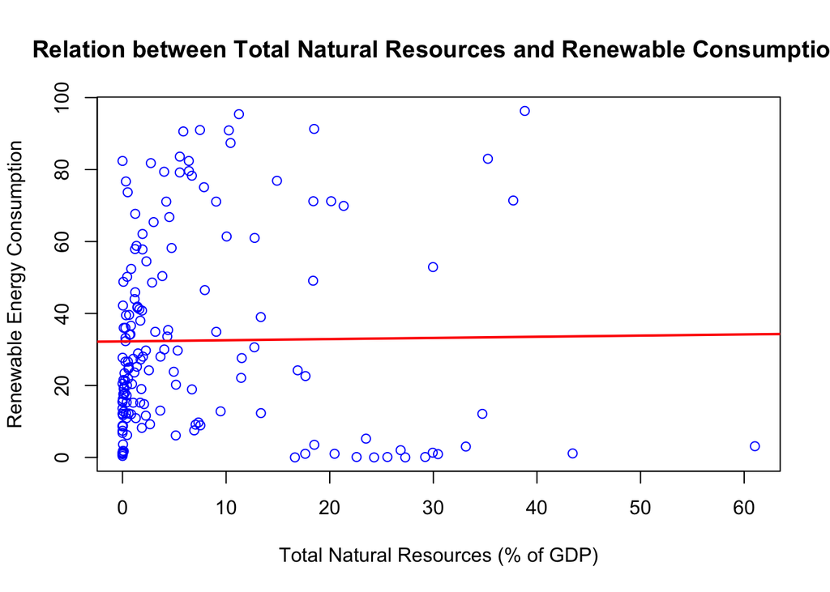

```r
plot(recentdata$Total_natural, recentdata$Renewable_energy_consumption,
     xlab = "Total Natural Resources (% of GDP)",
     ylab = "Renewable Energy Consumption",
     main = "Relation between Total Natural Resources and Renewable Consumption",
     col="blue")
abline(mod_nat_resources, col="red", lwd=2)
```

Most countries have natural resource rents below 10% of GDP, and their renewable shares are spread across the full range. The line is almost flat. Among the few countries with high resource rents (above 15%), some have renewable shares close to 0%, while others have shares above 70%, so they do not follow one clear direction.

```r
gvlma(mod_nat_resources)
```

```
##
## Call:
## lm(formula = Renewable_energy_consumption ~ Total_natural, data = recentdata)
##
## Coefficients:
##   (Intercept)  Total_natural
##      32.23604        0.03231
##
##
## ASSESSMENT OF THE LINEAR MODEL ASSUMPTIONS
## USING THE GLOBAL TEST ON 4 DEGREES-OF-FREEDOM:
## Level of Significance =  0.05
##
## Call:
##  gvlma(x = mod_nat_resources)
##
##                      Value   p-value                   Decision
## Global Stat        23.6767 9.272e-05 Assumptions NOT satisfied!
## Skewness           14.6099 1.322e-04 Assumptions NOT satisfied!
## Kurtosis            2.3565 1.248e-01    Assumptions acceptable.
## Link Function       5.9445 1.476e-02 Assumptions NOT satisfied!
## Heteroscedasticity  0.7659 3.815e-01    Assumptions acceptable.
```

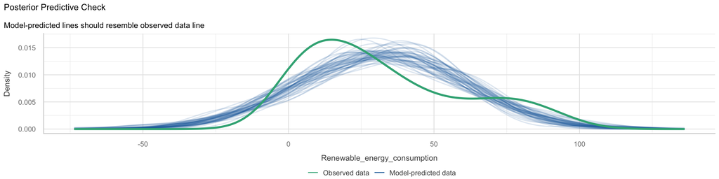

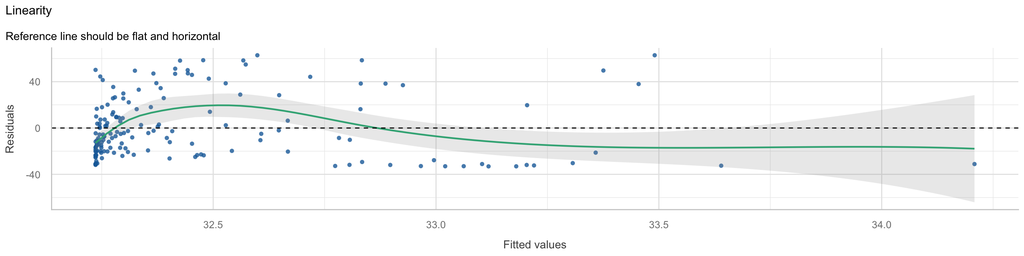

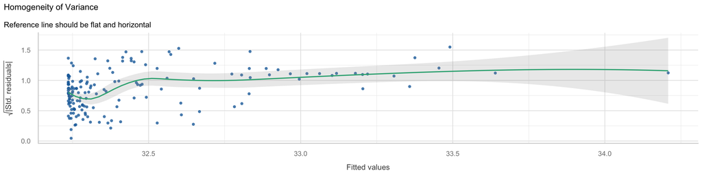

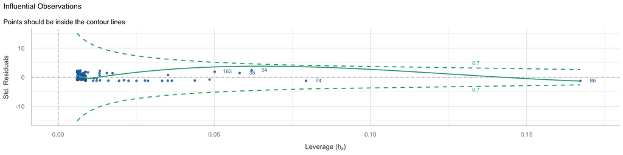

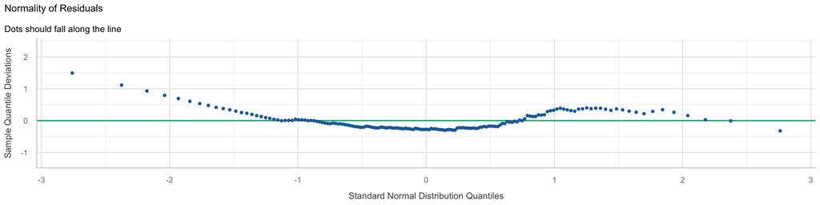

```r
plot(check_model(mod_nat_resources, panel = FALSE))
```

```r
mod_trade <- lm(Renewable_energy_consumption ~ Trade_GDP, data = recentdata)
stargazer(mod_trade, type="text",
          title ="Table 8: OLS results for Renewable Energy Consumption and Trade as % of GDP")
```

```
##
## Table 8: OLS results for Renewable Energy Consumption and Trade as % of GDP
## ================================================
##                         Dependent variable:
##                     ----------------------------
##                     Renewable_energy_consumption
## ------------------------------------------------
## Trade_GDP                    -0.142***
##                               (0.034)
##
## Constant                     45.107***
##                               (3.647)
##
## ------------------------------------------------
## Observations                    164
## R2                             0.096
## Adjusted R2                    0.091
## Residual Std. Error      25.684 (df = 162)
## F Statistic           17.233*** (df = 1; 162)
## ================================================
## Note:                *p<0.1; **p<0.05; ***p<0.01
```

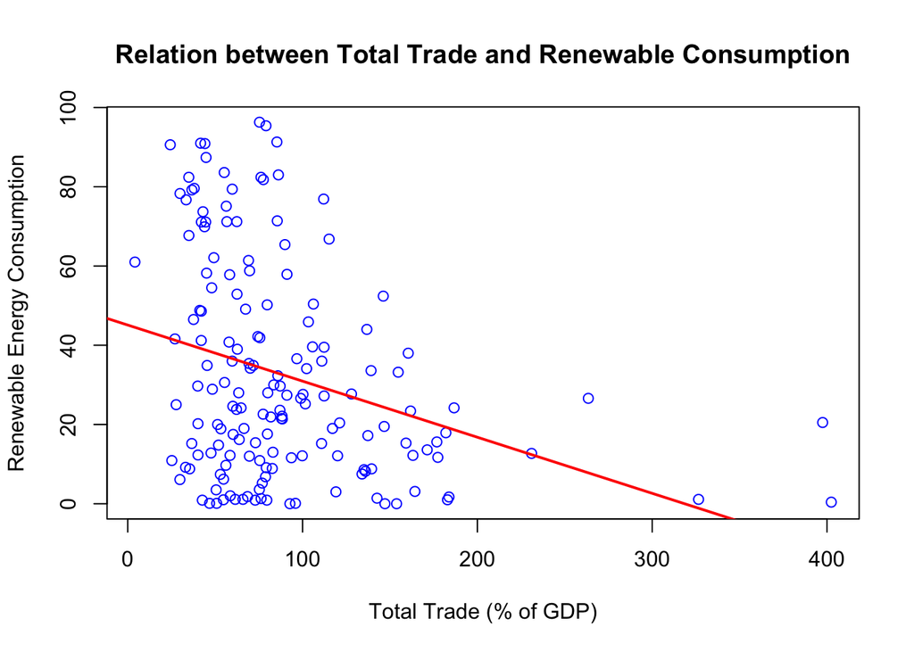

```r
plot(recentdata$Trade_GDP, recentdata$Renewable_energy_consumption,
     xlab = "Total Trade (% of GDP)",
     ylab = "Renewable Energy Consumption",
     main = "Relation between Total Trade and Renewable Consumption",
     col="blue")
abline(mod_trade, col="red", lwd=2)
```

Most countries have trade between about 25% and 150% of GDP. Countries with very high renewable shares are mostly at the lower end of trade. A few countries with extremely high trade (above 300% of GDP) have very low renewable shares, and they pull the line down. The line also falls below zero at the highest trade levels.

**Model Fit**

```r
gvlma(mod_trade)
```

```
##
## Call:
## lm(formula = Renewable_energy_consumption ~ Trade_GDP, data = recentdata)
##
## Coefficients:
## (Intercept)    Trade_GDP
##     45.1072      -0.1416
##
##
## ASSESSMENT OF THE LINEAR MODEL ASSUMPTIONS
## USING THE GLOBAL TEST ON 4 DEGREES-OF-FREEDOM:
## Level of Significance =  0.05
##
## Call:
##  gvlma(x = mod_trade)
##
##                      Value  p-value                   Decision
## Global Stat        15.2398 0.004229 Assumptions NOT satisfied!
## Skewness            8.5879 0.003384 Assumptions NOT satisfied!
## Kurtosis            2.7403 0.097848    Assumptions acceptable.
## Link Function       3.4877 0.061825    Assumptions acceptable.
## Heteroscedasticity  0.4239 0.515022    Assumptions acceptable.
```

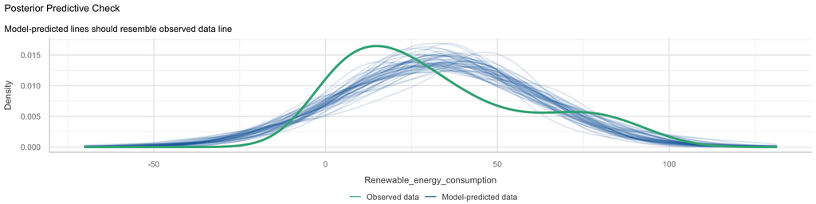

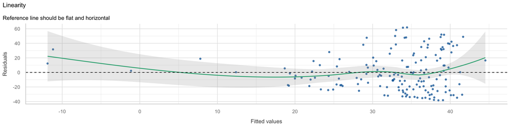

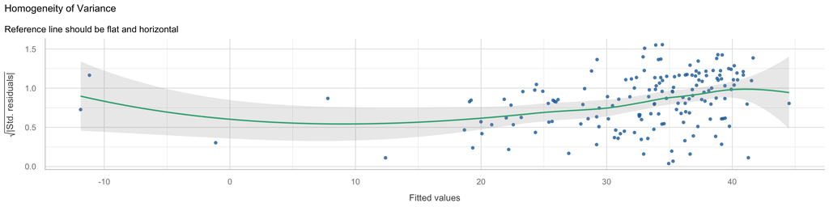

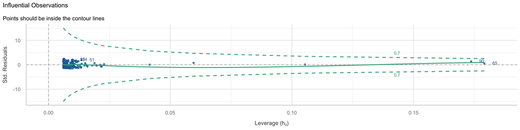

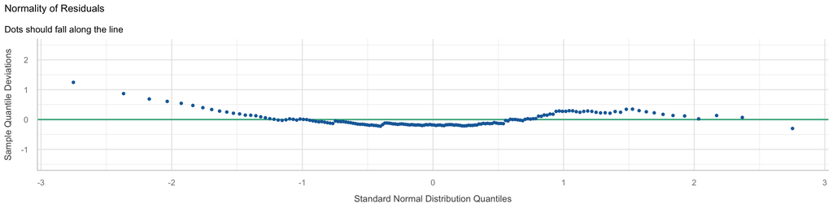

```r
plot(check_model(mod_trade, panel = FALSE))
```

The skewness test is significant (p-value = 0.00338), indicating asymmetric residuals. However, kurtosis (p-value = 0.0978), link function (p-value = 0.0618) and heteroscedasticity (p-value = 0.515) are not significant at the 5% level. The link-function p-value is relatively close to the 5% threshold, but it does not constitute a statistically significant violation at this level. Therefore, **skewness** is the main issue identified.

We try using logarithms in this case  
**Table 9 :***Renewable Energy Consumption and log of trade*

```r
mod_log_trade <-lm(Renewable_energy_consumption ~ log(Trade_GDP), data =recentdata)
stargazer(mod_log_trade, type="text",
          title ="Table 9: OLS results for Renewable Energy Consumption and log(Trade as % of GDP)")
```

```
##
## Table 9: OLS results for Renewable Energy Consumption and log(Trade as % of GDP)
## ================================================
##                         Dependent variable:
##                     ----------------------------
##                     Renewable_energy_consumption
## ------------------------------------------------
## log(Trade_GDP)               -15.500***
##                               (3.409)
##
## Constant                     99.490***
##                               (14.875)
##
## ------------------------------------------------
## Observations                    164
## R2                             0.113
## Adjusted R2                    0.108
## Residual Std. Error      25.441 (df = 162)
## F Statistic           20.672*** (df = 1; 162)
## ================================================
## Note:                *p<0.1; **p<0.05; ***p<0.01
```

**Scatter Plot**

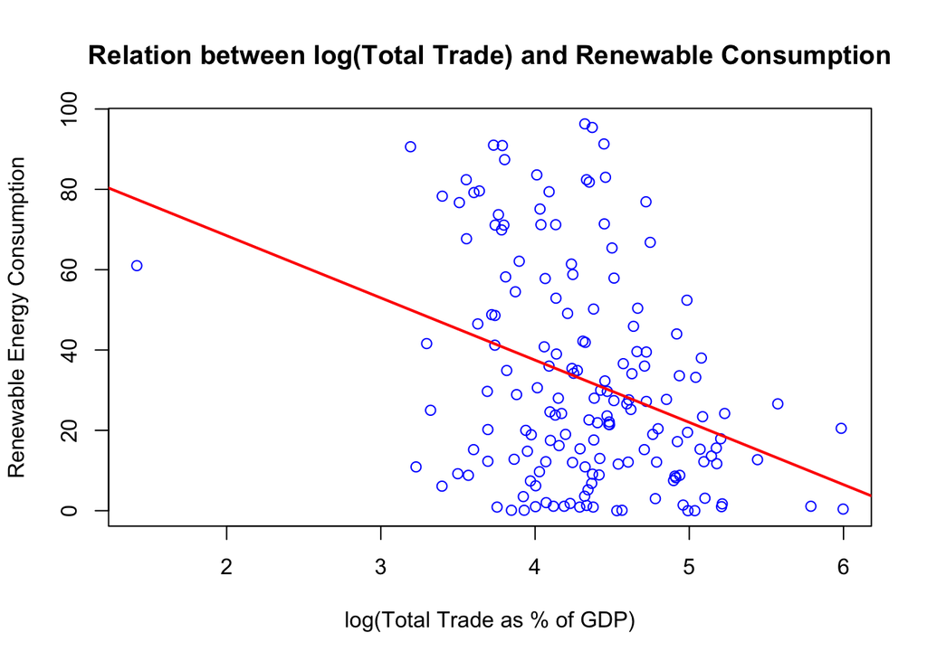

```r
plot(log(recentdata$Trade_GDP), recentdata$Renewable_energy_consumption,
     xlab = "log(Total Trade as % of GDP)",
     ylab = "Renewable Energy Consumption",
     main = "Relation between log(Total Trade) and Renewable Consumption",
     col="blue")
abline(mod_log_trade, col="red", lwd=2)
```

After taking the log, countries are spread out more evenly, and the very high trade countries no longer pull the line as much. However, there is now one country on the far left with very low trade and a high renewable share, which has a strong effect on the left end of the line. The points are still widely scattered, which explains why the R² is only slightly higher.

**Model Fit**

```r
gvlma(mod_log_trade)
```

```
##
## Call:
## lm(formula = Renewable_energy_consumption ~ log(Trade_GDP), data = recentdata)
##
## Coefficients:
##    (Intercept)  log(Trade_GDP)
##          99.49          -15.50
##
##
## ASSESSMENT OF THE LINEAR MODEL ASSUMPTIONS
## USING THE GLOBAL TEST ON 4 DEGREES-OF-FREEDOM:
## Level of Significance =  0.05
##
## Call:
##  gvlma(x = mod_log_trade)
##
##                      Value  p-value                   Decision
## Global Stat        10.7376 0.029677 Assumptions NOT satisfied!
## Skewness            8.3917 0.003769 Assumptions NOT satisfied!
## Kurtosis            1.6850 0.194255    Assumptions acceptable.
## Link Function       0.3933 0.530545    Assumptions acceptable.
## Heteroscedasticity  0.2675 0.605004    Assumptions acceptable.
```

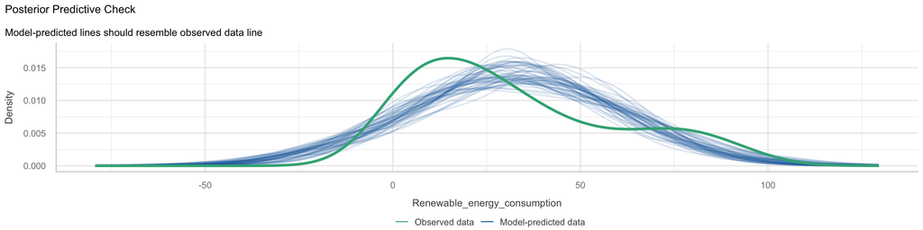

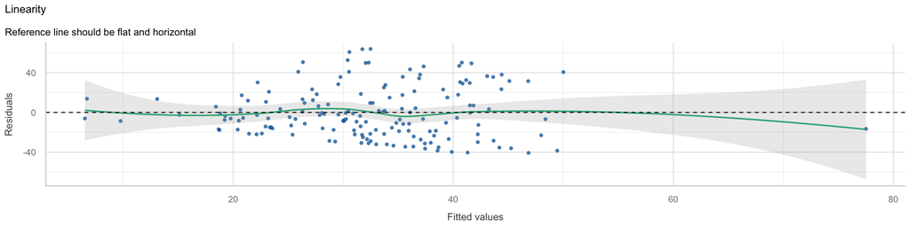

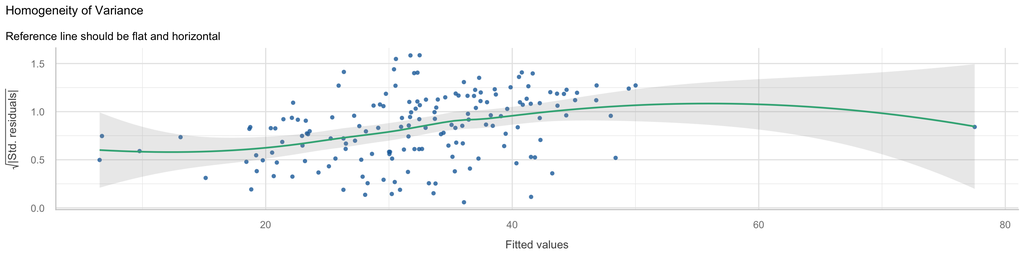

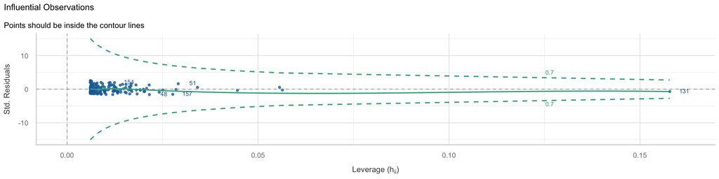

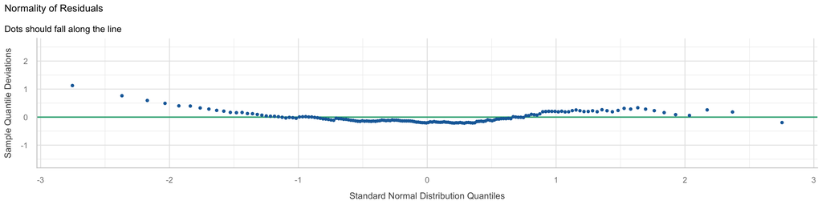

```r
plot(check_model(mod_log_trade, panel = FALSE))
```

The global test is significant, meaning that the model still does not satisfy all the assumptions jointly. The skewness test remains significant (p-value = 0.00377), while kurtosis (p-value = 0.194), link function (p-value = 0.531) and heteroscedasticity (p = 0.605) are acceptable. Compared with the model using untransformed trade, the logarithmic transformation improves the link-function result. However, the skewness problem remains, and the global test still rejects the overall assumptions.  
**Renewable Energy Consumption and Foreign direct investment**  
**Table 10 :** OLS results for Renewable Energy Consumption and Foreign direct investment

```r
mod_foreign_investment <- lm(Renewable_energy_consumption ~ Foreign_direct_investment, data = recentdata)
summary(mod_foreign_investment)
```

```
##
## Call:
## lm(formula = Renewable_energy_consumption ~ Foreign_direct_investment,
##     data = recentdata)
##
## Residuals:
##     Min      1Q  Median      3Q     Max
## -34.517 -21.714  -7.774  17.018  63.872
##
## Coefficients:
##                           Estimate Std. Error t value Pr(>|t|)
## (Intercept)                34.2548     2.5199  13.594   <2e-16 ***
## Foreign_direct_investment  -0.4303     0.3348  -1.285    0.201
## ---
## Signif. codes:  0 '***' 0.001 '**' 0.01 '*' 0.05 '.' 0.1 ' ' 1
##
## Residual standard error: 26.88 on 162 degrees of freedom
## Multiple R-squared:  0.01009,    Adjusted R-squared:  0.003982
## F-statistic: 1.652 on 1 and 162 DF,  p-value: 0.2006
```

```r
stargazer(mod_foreign_investment, type="text",
          title ="Table 10: OLS results for Renewable Energy Consumption and Foreign direct investment")
```

```
##
## Table 10: OLS results for Renewable Energy Consumption and Foreign direct investment
## ======================================================
##                               Dependent variable:
##                           ----------------------------
##                           Renewable_energy_consumption
## ------------------------------------------------------
## Foreign_direct_investment            -0.430
##                                     (0.335)
##
## Constant                           34.255***
##                                     (2.520)
##
## ------------------------------------------------------
## Observations                          164
## R2                                   0.010
## Adjusted R2                          0.004
## Residual Std. Error            26.879 (df = 162)
## F Statistic                   1.652 (df = 1; 162)
## ======================================================
## Note:                      *p<0.1; **p<0.05; ***p<0.01
```

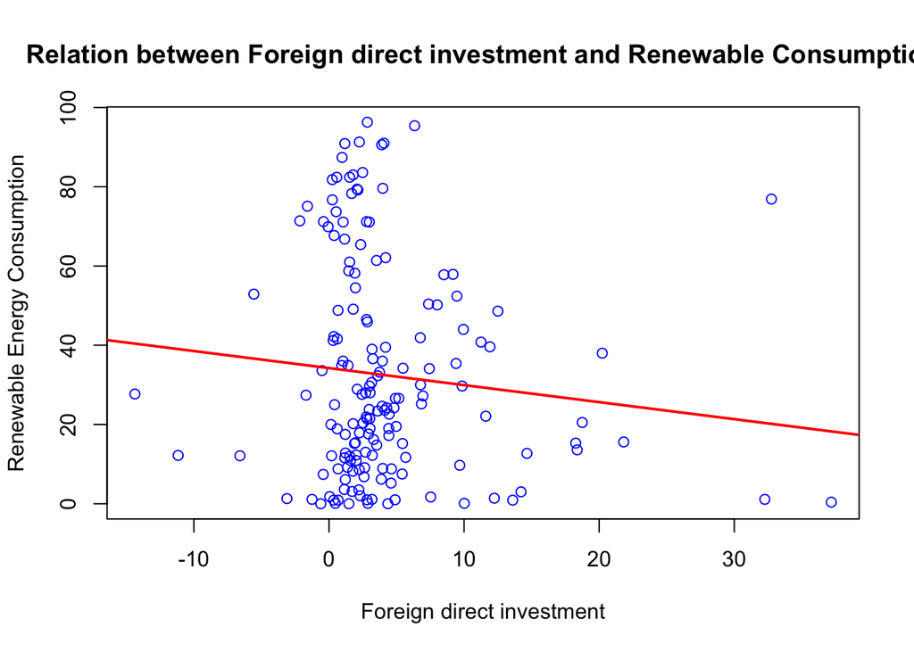

```r
plot(recentdata$Foreign_direct_investment, recentdata$Renewable_energy_consumption,
     xlab = "Foreign direct investment",
     ylab = "Renewable Energy Consumption",
     main = "Relation between Foreign direct investment and Renewable Consumption",
     col="blue")
abline(mod_foreign_investment, col="red", lwd=2)
```

**Model Fit**

```r
gvlma(mod_foreign_investment)
```

```
##
## Call:
## lm(formula = Renewable_energy_consumption ~ Foreign_direct_investment,
##     data = recentdata)
##
## Coefficients:
##               (Intercept)  Foreign_direct_investment
##                   34.2548                    -0.4303
##
##
## ASSESSMENT OF THE LINEAR MODEL ASSUMPTIONS
## USING THE GLOBAL TEST ON 4 DEGREES-OF-FREEDOM:
## Level of Significance =  0.05
##
## Call:
##  gvlma(x = mod_foreign_investment)
##
##                       Value   p-value                   Decision
## Global Stat        17.69901 0.0014129 Assumptions NOT satisfied!
## Skewness           14.66515 0.0001284 Assumptions NOT satisfied!
## Kurtosis            2.18072 0.1397487    Assumptions acceptable.
## Link Function       0.09472 0.7582593    Assumptions acceptable.
## Heteroscedasticity  0.75841 0.3838271    Assumptions acceptable.
```

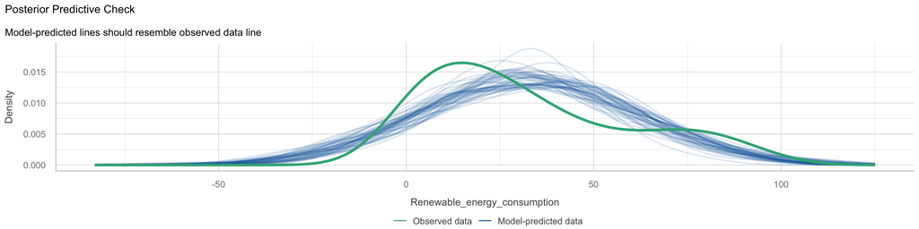

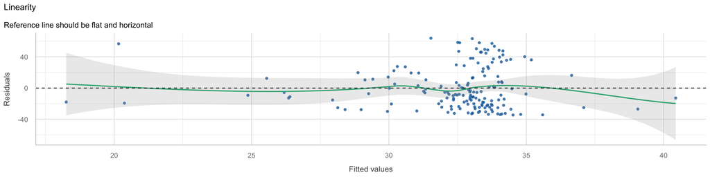

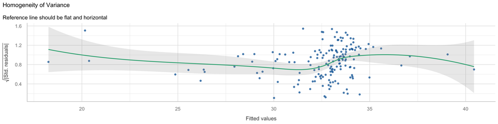

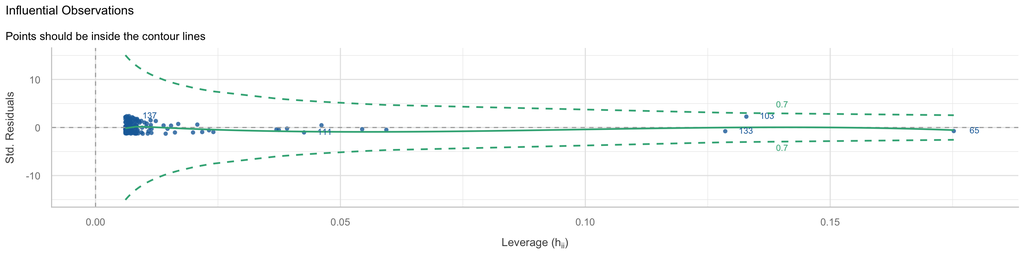

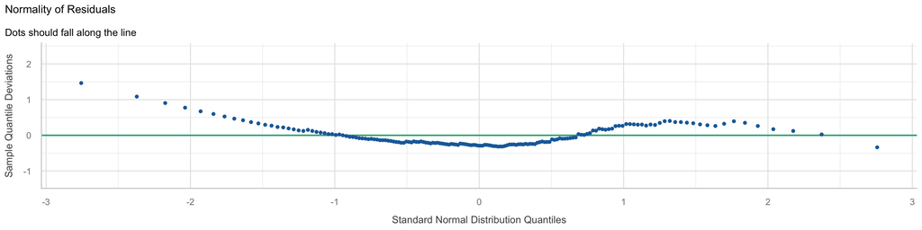

```r
plot(check_model(mod_foreign_investment, panel = FALSE))
```

Skewness is still the main issue identified by the validation test. Although, the model has very little explanatory power.

## Step 3 : Multivariable models and model selection

```r
mod_multiple <-lm(Renewable_energy_consumption ~
               log(GDP_per_capita) +
               Urban_pop +
               Gross_Capital +
               log(Trade_GDP) +
               Total_natural +
               Foreign_direct_investment ,
               data = recentdata)
stargazer(mod_multiple, type="text",
          title ="Table 11: Multivariable OLS results for Renewable Energy Consumption and the other variables")
```

```
##
## Table 11: Multivariable OLS results for Renewable Energy Consumption and the other variables
## ======================================================
##                               Dependent variable:
##                           ----------------------------
##                           Renewable_energy_consumption
## ------------------------------------------------------
## log(GDP_per_capita)                -9.493***
##                                     (1.991)
##
## Urban_pop                            -0.097
##                                     (0.125)
##
## Gross_Capital                        -0.045
##                                     (0.216)
##
## log(Trade_GDP)                      -6.083*
##                                     (3.505)
##
## Total_natural                        -0.248
##                                     (0.174)
##
## Foreign_direct_investment            0.199
##                                     (0.308)
##
## Constant                           149.614***
##                                     (16.322)
##
## ------------------------------------------------------
## Observations                          164
## R2                                   0.373
## Adjusted R2                          0.349
## Residual Std. Error            21.727 (df = 157)
## F Statistic                 15.579*** (df = 6; 157)
## ======================================================
## Note:                      *p<0.1; **p<0.05; ***p<0.01
```

**Model Fit**

```r
gvlma(mod_multiple)
```

```
##
## Call:
## lm(formula = Renewable_energy_consumption ~ log(GDP_per_capita) +
##     Urban_pop + Gross_Capital + log(Trade_GDP) + Total_natural +
##     Foreign_direct_investment, data = recentdata)
##
## Coefficients:
##               (Intercept)        log(GDP_per_capita)
##                 149.61447                   -9.49325
##                 Urban_pop              Gross_Capital
##                  -0.09701                   -0.04466
##            log(Trade_GDP)              Total_natural
##                  -6.08311                   -0.24832
## Foreign_direct_investment
##                   0.19909
##
##
## ASSESSMENT OF THE LINEAR MODEL ASSUMPTIONS
## USING THE GLOBAL TEST ON 4 DEGREES-OF-FREEDOM:
## Level of Significance =  0.05
##
## Call:
##  gvlma(x = mod_multiple)
##
##                      Value   p-value                   Decision
## Global Stat        32.5841 1.453e-06 Assumptions NOT satisfied!
## Skewness           11.8515 5.762e-04 Assumptions NOT satisfied!
## Kurtosis            0.8948 3.442e-01    Assumptions acceptable.
## Link Function      19.6466 9.317e-06 Assumptions NOT satisfied!
## Heteroscedasticity  0.1913 6.619e-01    Assumptions acceptable.
```

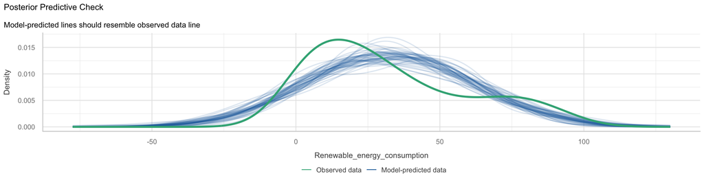

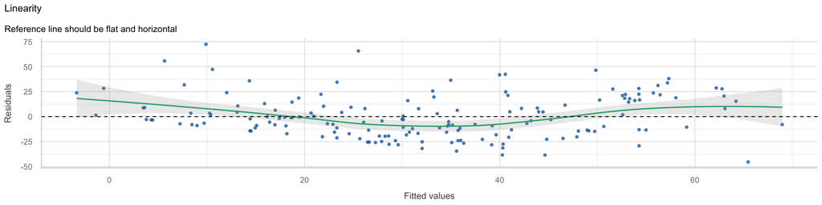

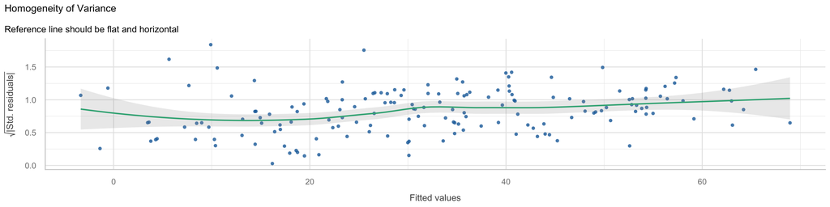

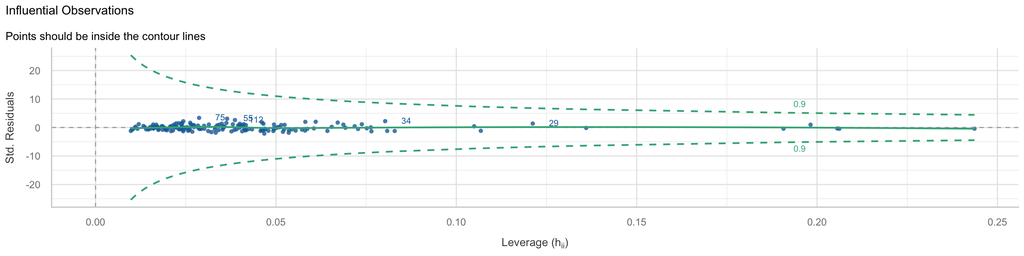

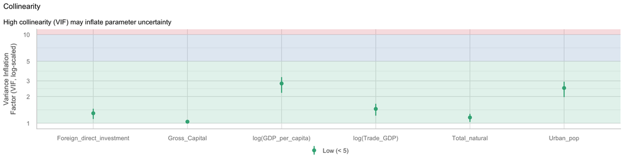

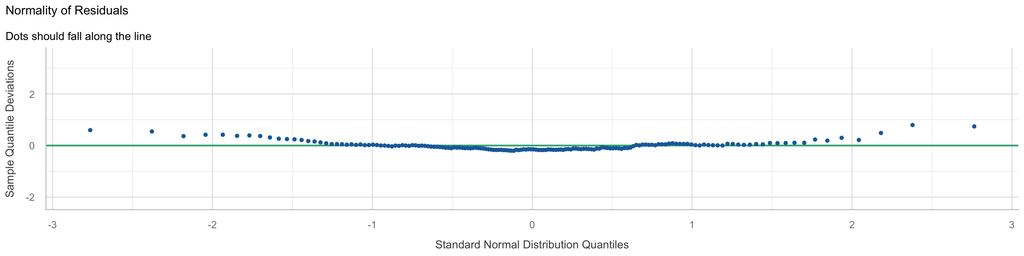

```r
plot(check_model(mod_multiple, panel = FALSE))
```

The global test is highly significant (p-value = 0.00000145) which shows that the multiple regression does not satisfy the assumptions jointly. The skewness test (p-value = 0.000576) is significant, suggesting asymmetric residuals. The kurtosis (p-value = 0.344) and heteroscedasticity (p-value = 0.662) tests are not significant. Therefore, despite having the highest R² among our models, the multiple regression model still presents some assumption violations.

Comparing the models we have

```r
model_comparison <- compare_performance(mod_gdp, mod_log_gdp, mod_gross_capital, mod_urban_pop, mod_log_urban_pop, mod_nat_resources,
                                        mod_trade, mod_log_trade, mod_foreign_investment, mod_multiple, rank = TRUE)
print_md(model_comparison)
```

Comparison of Model Performance Indices

| Name | Model | R2 | R2 (adj.) | RMSE | Sigma | AIC weights | AICc weights | BIC weights | Performance-Score |
| --- | --- | --- | --- | --- | --- | --- | --- | --- | --- |
| mod_log_gdp | lm | 0.35 | 0.34 | 21.72 | 21.85 | 0.816 | 0.868 | 1.000 | 97.14% |
| mod_multiple | lm | 0.37 | 0.35 | 21.26 | 21.73 | 0.183 | 0.132 | 9.68e-05 | 62.53% |
| mod_urban_pop | lm | 0.24 | 0.23 | 23.48 | 23.63 | 2.25e-06 | 2.39e-06 | 2.75e-06 | 36.28% |
| mod_log_urban_pop | lm | 0.23 | 0.22 | 23.57 | 23.72 | 1.17e-06 | 1.25e-06 | 1.43e-06 | 35.30% |
| mod_log_trade | lm | 0.11 | 0.11 | 25.29 | 25.44 | 1.20e-11 | 1.27e-11 | 1.46e-11 | 17.14% |
| mod_trade | lm | 0.10 | 0.09 | 25.53 | 25.68 | 2.52e-12 | 2.67e-12 | 3.08e-12 | 14.53% |
| mod_gdp | lm | 0.09 | 0.09 | 25.60 | 25.76 | 1.60e-12 | 1.70e-12 | 1.96e-12 | 13.76% |
| mod_foreign_investment | lm | 0.01 | 3.98e-03 | 26.71 | 26.88 | 1.45e-15 | 1.54e-15 | 1.78e-15 | 1.49% |
| mod_gross_capital | lm | 3.19e-04 | -5.85e-03 | 26.85 | 27.01 | 6.48e-16 | 6.89e-16 | 7.94e-16 | 0.02% |
| mod_nat_resources | lm | 1.60e-04 | -6.01e-03 | 26.85 | 27.01 | 6.40e-16 | 6.80e-16 | 7.84e-16 | 0.00% |

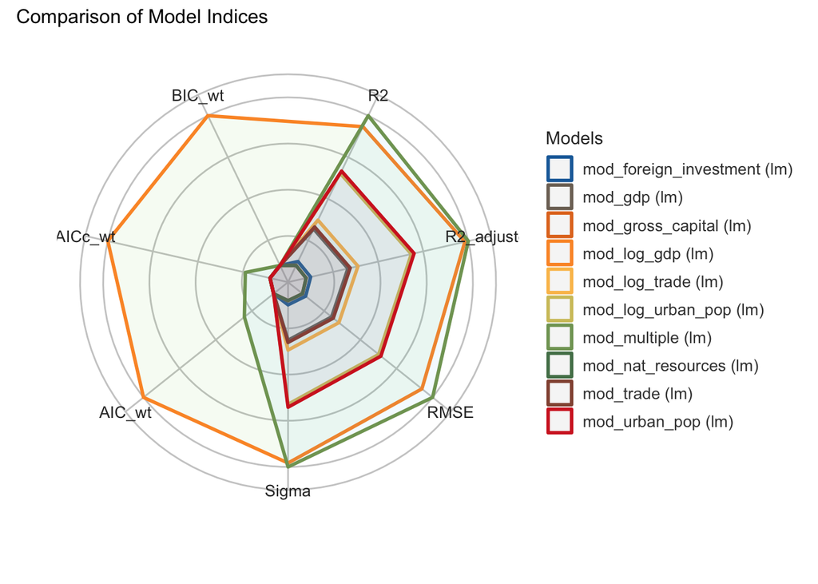

```r
par(mfrow = c(1, 1))
plot(model_comparison)
```

The radar chart shows the same comparison visually. Each axis is one performance measure, and points further from the centre mean better performance. The log GDP model has the largest area and performs well on every measure, so it fits the data best overall. The multivariable model does about as well on R², adjusted R², RMSE and sigma, but it is close to zero on the AIC and BIC weights, which shows that its extra variables are not worth the added complexity. Among the other single variable models, urbanisation performs best, followed by trade and linear GDP. The models for gross capital formation, natural resource rents and FDI stay close to the centre on every measure, so they fit the data worst.

## Conclusion

**On Model Fits** The “gvlma()” results show that all nine models for which we have test results fail the global validation test at the 5% significance level. The most consistent problem is skewness : every model has a significant skewness test. This suggests that the residual distributions are not sufficiently symmetric.

The log GDP model, which performs best among the simple regressions in terms of explanatory power, still fails the global validation test. Similarly, the multiple regression has a higher R² but also fails the global test. Therefore, we learned that we should not select a model based only on R², adjusted R² or statistical significance.

Overall, the log GDP model remains a useful choice for a relatively simple description of the relationship between income and renewable energy consumption, but its results must be interpreted with caution because the assumptions are not fully satisfied. Further investigation of the residual distribution and functional form would be necessary before relying strongly on conventional OLS inference. These tests also do not assess every possible regression concern, such as independence of observations or omitted-variable bias ; which show up only in an in-depth analysis.  
**Limitations**  
A large limitation of this analysis is that all countries were pooled into a single cross-sectional model, regardless of income and development status. This assumes that the association between economic factors and renewable energy use is the same in every country across the world, which does not reflect the true complexity of the interactions between development, investment and resource use. In fact, the inconsistent findings across previous research may be partly explained by the fact that studies have focused on different groups of countries. Osińska et al. (2024) illustrate a more robust approach, where countries are disaggregated according to the Human Development Index. They find that the determinants of renewable energy consumption differ substantially between groups of countries that are at different levels of human development. The results from this analysis therefore represent average associations across a highly diverse sample, which may hide more complex relationships within the sample. Therefore, following Osińska et al. (2024), future models should group countries by income level, Human Development Index or similar development indicators, in order to analyse finer variations within these groups.  
Furthermore, because the analysis uses data from only one year, the results only indicate association and no conclusions regarding causal links can be drawn. Time lags also cannot be captured, which may be an issue for the explanatory power of gross capital formation, as investment in new renewable capacity may take some time to affect energy consumption. Thus, in order to evaluate effects over time, as well as lagged impacts, future research could use panel data spanning several years.  
In addition, the measurement of the dependent variable is problematic, due to the nature of the available dataset. The World Bank’s share of renewable energy in final energy consumption counts biofuels such as charcoal and wood as renewable energy (World Bank, 2015). In many developing countries these fuels account for a large share of final energy consumption, and thus the share of renewable energy used in these countries may be inflated (International Energy Agency, 2026). It is thus more likely to reflect energy poverty than progress towards a sustainable energy transition. Future research should therefore assure that the dependent variable is restricted to modern renewables such as solar, wind, hydropower and geothermal energy.  
Lastly, future research could examine the interaction of socio-cultural factors, such as environmental awareness, with the economic factors studied here, to give a more complete picture of the drivers behind renewable energy adoption.  
2021 year falls in the post-COVID recovery, where trade volumes and FDI flows were still volatile, and commodity prices were rising from their 2020 lows. Thus, resource rents in 2021 may differ from their long-run levels.

**References**  
Aidoo, L. (2024). Examining the determinants of renewable energy consumption in the southern African power pool. Managing Global Transitions, 22(2). https://doi.org/10.26493/1854-6935.22.121-142  
Ergun, S. J., & Rivas, M. F. (2023). Does higher income lead to more renewable energy consumption? Evidence from emerging-Asian countries. Heliyon, 9(1), e13049. https://doi.org/10.1016/j.heliyon.2023.e13049  
International Energy Agency. (2024). Reducing the cost of capital: Strategies to unlock clean energy investment in emerging and developing economies. In International Energy Agency Reports. International Energy Agency. https://www.proquest.com/docview/3146999884  
International Energy Agency. (2026). Africa – Energy Mix. IEA. https://www.iea.org/regions/africa/energy-mix  
OECD. (2025). Investment (GFCF). OECD. https://www.oecd.org/en/data/indicators/investment-gfcf.html  
Osińska, M., Khan, A. M., & Kwiatkowski, J. (2024). Identifying economic factors of renewable energy consumption—A global perspective. Energies, 17(15), 3715. https://doi.org/10.3390/en17153715  
Our World in Data. (2026). Share of final energy use that comes from renewable sources. Our World in Data. https://ourworldindata.org/grapher/share-of-final-energy-consumption-from-renewable-sources  
Renewable Energy Institute. (2025). Renewable Energy Insights - The Importance of Renewable Energy for the Future. The Renewable Energy Institute. https://www.renewableinstitute.org/the-importance-of-renewable-energy-for-the-future/  
Shahzad, U., Radulescu, M., Rahim, S., Isik, C., Yousaf, Z., & Ionescu, S. (2021). Do Environment-Related Policy Instruments and Technologies Facilitate Renewable Energy Generation? Exploring the Contextual Evidence from Developed Economies. Energies, 14(3), 690. https://doi.org/10.3390/en14030690  
World Bank. (2015). Metadata. Worldbank.Org. https://databank.worldbank.org/metadataglossary/sustainable-energy-for-all/series/3.1_RE.CONSUMPTION  
Wu, H., Mentel, U., Lew, G., & Wang, S. (2022). What drives renewable energy in the group of seven economies? Evidence from non-parametric panel methods. Economic Research-Ekonomska Istraživanja, 36(1), 1708–1734. https://doi.org/10.1080/1331677x.2022.2092525